# LBB3

Reynard Verill

January 16, 2021

# Library and Setup

```r
library(tidyverse)
library(gtools)
library(caret)
library(GGally)
library(car)

theme_set(theme_minimal() +
            theme(legend.position = "top"))

options(scipen = 999)
```

# Training Objectives

The objectives of this report is to understand the correlation between the crime rate of an area and its socioeconomic variables. This report is going to analyze the different predictor variables that are available in the data crime.csv, which is a collection of crime related data in 1960, towards the ‘crime_rate’ target variable.

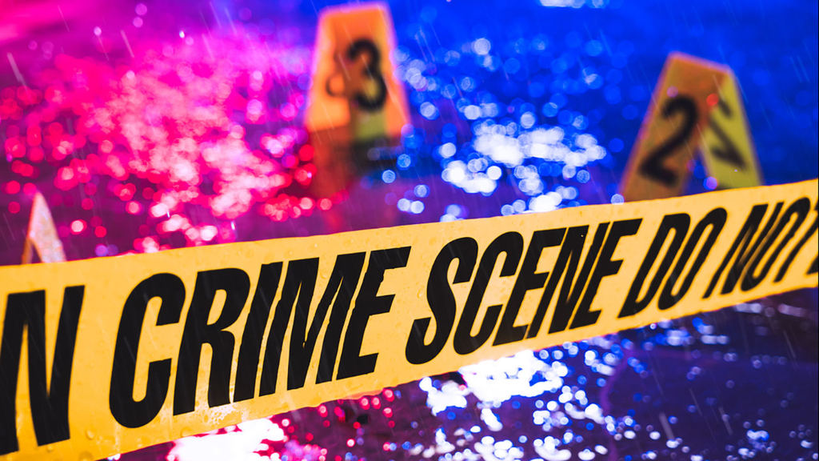

```r
crime <- read.csv("data_input/crime.csv")

#remoce x from the data frame as it is only a unique id
crime <- crime %>%
  select(-c(X)) %>%
  setNames(c("percent_m", "is_south", "mean_education", "police_exp60",
             "police_exp59", "labour_participation", "m_per1000f", "state_pop",
             "nonwhites_per1000", "unemploy_m24", "unemploy_m39", "gdp", "inequality",
             "prob_prison", "time_prison", "crime_rate"))


glimpse(crime)
```

```
## Rows: 47
## Columns: 16
## $ percent_m            <int> 151, 143, 142, 136, 141, 121, 127, 131, 157, 140…
## $ is_south             <int> 1, 0, 1, 0, 0, 0, 1, 1, 1, 0, 0, 0, 0, 0, 1, 1, …
## $ mean_education       <int> 91, 113, 89, 121, 121, 110, 111, 109, 90, 118, 1…
## $ police_exp60         <int> 58, 103, 45, 149, 109, 118, 82, 115, 65, 71, 121…
## $ police_exp59         <int> 56, 95, 44, 141, 101, 115, 79, 109, 62, 68, 116,…
## $ labour_participation <int> 510, 583, 533, 577, 591, 547, 519, 542, 553, 632…
## $ m_per1000f           <int> 950, 1012, 969, 994, 985, 964, 982, 969, 955, 10…
## $ state_pop            <int> 33, 13, 18, 157, 18, 25, 4, 50, 39, 7, 101, 47, …
## $ nonwhites_per1000    <int> 301, 102, 219, 80, 30, 44, 139, 179, 286, 15, 10…
## $ unemploy_m24         <int> 108, 96, 94, 102, 91, 84, 97, 79, 81, 100, 77, 8…
## $ unemploy_m39         <int> 41, 36, 33, 39, 20, 29, 38, 35, 28, 24, 35, 31, …
## $ gdp                  <int> 394, 557, 318, 673, 578, 689, 620, 472, 421, 526…
## $ inequality           <int> 261, 194, 250, 167, 174, 126, 168, 206, 239, 174…
## $ prob_prison          <dbl> 0.084602, 0.029599, 0.083401, 0.015801, 0.041399…
## $ time_prison          <dbl> 26.2011, 25.2999, 24.3006, 29.9012, 21.2998, 20.…
## $ crime_rate           <int> 791, 1635, 578, 1969, 1234, 682, 963, 1555, 856,…
```

Data Description:

- `percent_m`: percentage of males aged 14-24
- `is_south`: whether it is in a Southern state. 1 for Yes, 0 for No.
- `mean_education`: mean years of schooling
- `police_exp60`: police expenditure in 1960
- `police_exp59`: police expenditure in 1959
- `labour_participation`: labour force participation rate
- `m_per1000f`: number of males per 1000 females
- `state_pop`: state population
- `nonwhites_per1000`: number of non-whites resident per 1000 people
- `unemploy_m24`: unemployment rate of urban males aged 14-24
- `unemploy_m39`: unemployment rate of urban males aged 35-39
- `gdp`: gross domestic product per head
- `inequality`: income inequality
- `prob_prison`: probability of imprisonment
- `time_prison`: avg time served in prisons
- `crime_rate`: crime rate in an unspecified category Produce a linear model

Here, we can see the strength of the correlation of each variables by using ggcorr

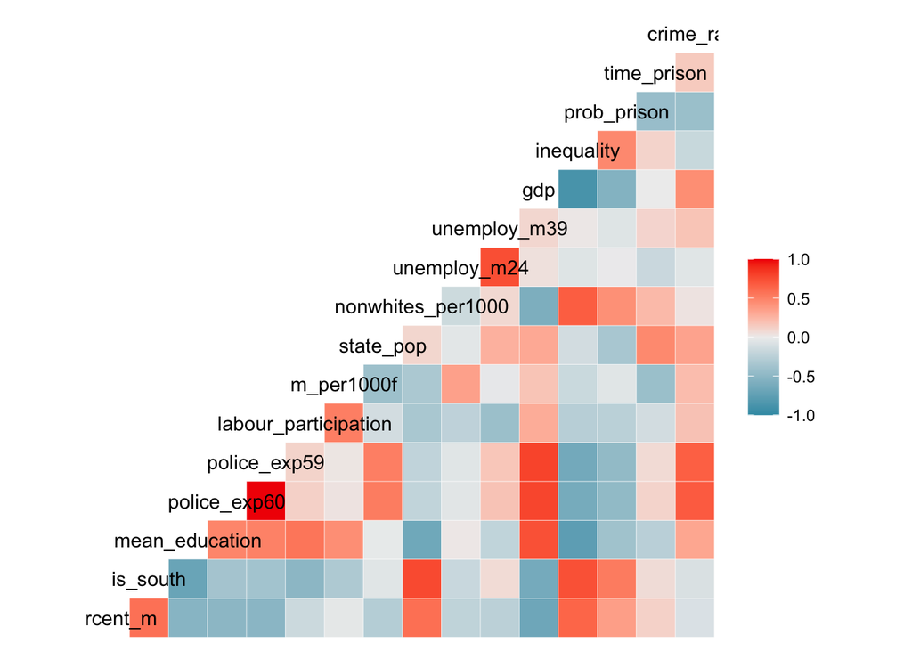

```r
ggcorr(crime)
```

Then, we can choose which variables are most suitable for our analysis

```r
model_crime <- lm(crime_rate ~ ., crime)
summary(model_crime)
```

```
##
## Call:
## lm(formula = crime_rate ~ ., data = crime)
##
## Residuals:
##     Min      1Q  Median      3Q     Max
## -395.74  -98.09   -6.69  112.99  512.67
##
## Coefficients:
##                        Estimate Std. Error t value Pr(>|t|)
## (Intercept)          -5984.2876  1628.3184  -3.675 0.000893 ***
## percent_m                8.7830     4.1714   2.106 0.043443 *
## is_south                -3.8035   148.7551  -0.026 0.979765
## mean_education          18.8324     6.2088   3.033 0.004861 **
## police_exp60            19.2804    10.6110   1.817 0.078892 .
## police_exp59           -10.9422    11.7478  -0.931 0.358830
## labour_participation    -0.6638     1.4697  -0.452 0.654654
## m_per1000f               1.7407     2.0354   0.855 0.398995
## state_pop               -0.7330     1.2896  -0.568 0.573845
## nonwhites_per1000        0.4204     0.6481   0.649 0.521279
## unemploy_m24            -5.8271     4.2103  -1.384 0.176238
## unemploy_m39            16.7800     8.2336   2.038 0.050161 .
## gdp                      0.9617     1.0367   0.928 0.360754
## inequality               7.0672     2.2717   3.111 0.003983 **
## prob_prison          -4855.2658  2272.3746  -2.137 0.040627 *
## time_prison             -3.4790     7.1653  -0.486 0.630708
## ---
## Signif. codes:  0 '***' 0.001 '**' 0.01 '*' 0.05 '.' 0.1 ' ' 1
##
## Residual standard error: 209.1 on 31 degrees of freedom
## Multiple R-squared:  0.8031, Adjusted R-squared:  0.7078
## F-statistic: 8.429 on 15 and 31 DF,  p-value: 0.0000003539
```

```r
step_crime <-step(model_crime)
```

```
## Start:  AIC=514.65
## crime_rate ~ percent_m + is_south + mean_education + police_exp60 +
##     police_exp59 + labour_participation + m_per1000f + state_pop +
##     nonwhites_per1000 + unemploy_m24 + unemploy_m39 + gdp + inequality +
##     prob_prison + time_prison
##
##                        Df Sum of Sq     RSS    AIC
## - is_south              1        29 1354974 512.65
## - labour_participation  1      8917 1363862 512.96
## - time_prison           1     10304 1365250 513.00
## - state_pop             1     14122 1369068 513.14
## - nonwhites_per1000     1     18395 1373341 513.28
## - m_per1000f            1     31967 1386913 513.74
## - gdp                   1     37613 1392558 513.94
## - police_exp59          1     37919 1392865 513.95
## <none>                              1354946 514.65
## - unemploy_m24          1     83722 1438668 515.47
## - police_exp60          1    144306 1499252 517.41
## - unemploy_m39          1    181536 1536482 518.56
## - percent_m             1    193770 1548716 518.93
## - prob_prison           1    199538 1554484 519.11
## - mean_education        1    402117 1757063 524.86
## - inequality            1    423031 1777977 525.42
##
## Step:  AIC=512.65
## crime_rate ~ percent_m + mean_education + police_exp60 + police_exp59 +
##     labour_participation + m_per1000f + state_pop + nonwhites_per1000 +
##     unemploy_m24 + unemploy_m39 + gdp + inequality + prob_prison +
##     time_prison
##
##                        Df Sum of Sq     RSS    AIC
## - time_prison           1     10341 1365315 511.01
## - labour_participation  1     10878 1365852 511.03
## - state_pop             1     14127 1369101 511.14
## - nonwhites_per1000     1     21626 1376600 511.39
## - m_per1000f            1     32449 1387423 511.76
## - police_exp59          1     37954 1392929 511.95
## - gdp                   1     39223 1394197 511.99
## <none>                              1354974 512.65
## - unemploy_m24          1     96420 1451395 513.88
```

[output cut: 100 more lines]

```
##
## Step:  AIC=503.93
## crime_rate ~ percent_m + mean_education + police_exp60 + m_per1000f +
##     unemploy_m24 + unemploy_m39 + inequality + prob_prison
##
##                  Df Sum of Sq     RSS    AIC
## <none>                        1453068 503.93
## - m_per1000f      1    103159 1556227 505.16
## - unemploy_m24    1    127044 1580112 505.87
## - prob_prison     1    247978 1701046 509.34
## - unemploy_m39    1    255443 1708511 509.55
## - percent_m       1    296790 1749858 510.67
## - mean_education  1    445788 1898855 514.51
## - inequality      1    738244 2191312 521.24
## - police_exp60    1   1672038 3125105 537.93
```

```r
summary(step_crime, trace = 0)
```

```
##
## Call:
## lm(formula = crime_rate ~ percent_m + mean_education + police_exp60 +
##     m_per1000f + unemploy_m24 + unemploy_m39 + inequality + prob_prison,
##     data = crime)
##
## Residuals:
##     Min      1Q  Median      3Q     Max
## -444.70 -111.07    3.03  122.15  483.30
##
## Coefficients:
##                 Estimate Std. Error t value     Pr(>|t|)
## (Intercept)    -6426.101   1194.611  -5.379 0.0000040395 ***
## percent_m          9.332      3.350   2.786      0.00828 **
## mean_education    18.012      5.275   3.414      0.00153 **
## police_exp60      10.265      1.552   6.613 0.0000000826 ***
## m_per1000f         2.234      1.360   1.642      0.10874
## unemploy_m24      -6.087      3.339  -1.823      0.07622 .
## unemploy_m39      18.735      7.248   2.585      0.01371 *
## inequality         6.133      1.396   4.394 0.0000863344 ***
## prob_prison    -3796.032   1490.646  -2.547      0.01505 *
## ---
## Signif. codes:  0 '***' 0.001 '**' 0.01 '*' 0.05 '.' 0.1 ' ' 1
##
## Residual standard error: 195.5 on 38 degrees of freedom
## Multiple R-squared:  0.7888, Adjusted R-squared:  0.7444
## F-statistic: 17.74 on 8 and 38 DF,  p-value: 0.0000000001159
```

# Normality tests

Next, we can test the normality of the residuals of the data frame by using the function hist

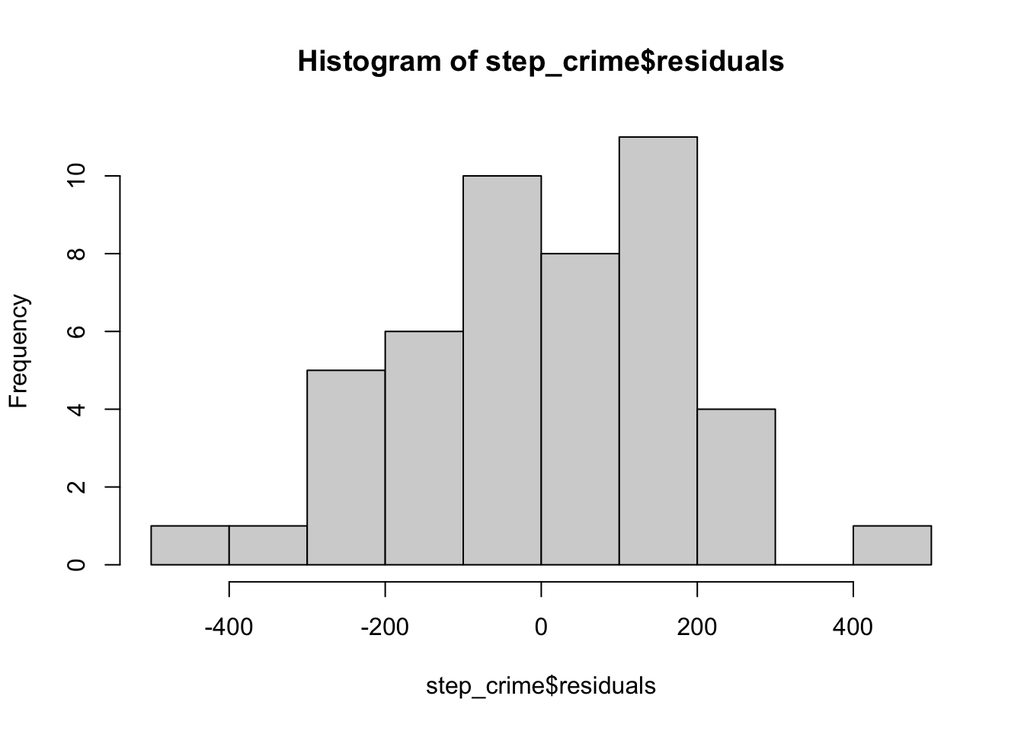

```r
hist(step_crime$residuals)
```

And we can also use shapiro test to determine whether the residuals are normally distributed or not. * p-value < 0.05 : Not normally distributed * p-value > 0.05 : Normally distributed

```r
shapiro.test(step_crime$residuals)
```

```
##
##  Shapiro-Wilk normality test
##
## data:  step_crime$residuals
## W = 0.98511, p-value = 0.8051
```

From the shapiro-wilk normality test, it can be inferred that the residuals are normally distributed as the p-value stands high at 0.8051.

```r
library(nortest)
ad.test(step_crime$residuals)
```

```
##
##  Anderson-Darling normality test
##
## data:  step_crime$residuals
## A = 0.2776, p-value = 0.637
```

Similarly, the ad.test function also generates a p-value greater than 0.05

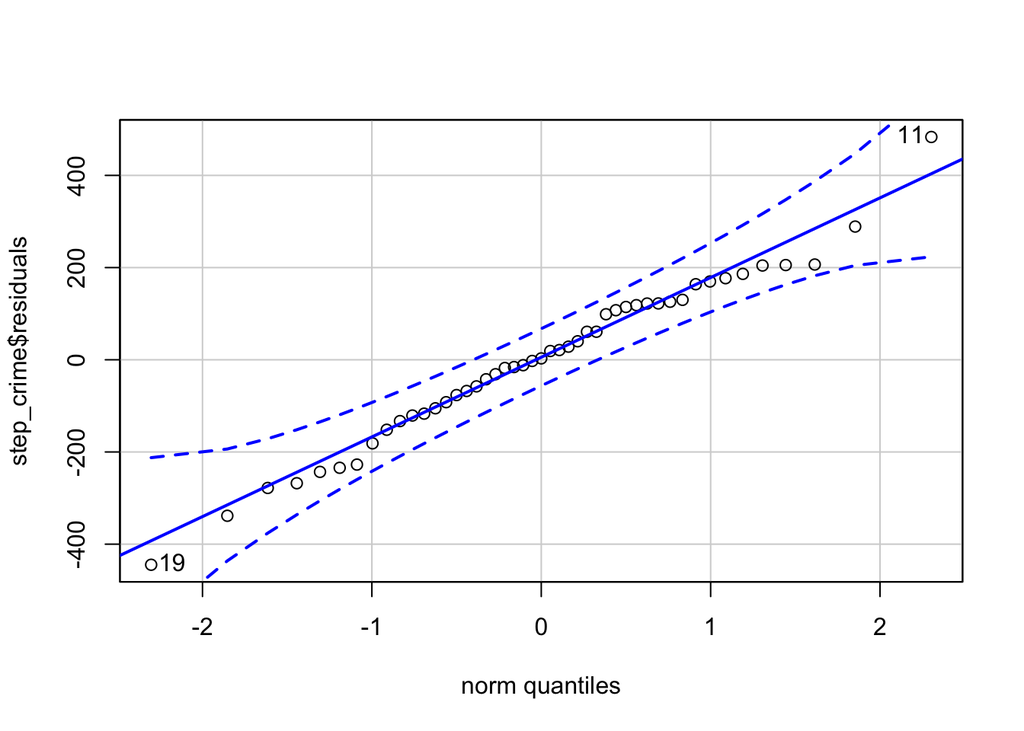

```
## [1] 11 19
```

```r
qqPlot(step_crime$residuals)
```

Additionally, when we try to plot the residuals using the qqPlot function, all the dots are scattered within the blue line, which concludes that they are distributed normally. Hence, the normality assumptions have been satisfied as shown above.

# Prediction

```r
step_crime$coefficients
```

```
##    (Intercept)      percent_m mean_education   police_exp60     m_per1000f
##   -6426.101018       9.332155      18.012011      10.265316       2.233975
##   unemploy_m24   unemploy_m39     inequality    prob_prison
##      -6.086633      18.734512       6.133494   -3796.031826
```

As the normality assumptions have been completed, we are able to obtain the coefficients from the linear regression of the predictor variables.

```r
pred_crime <- predict(step_crime, crime)

head(pred_crime)
```

```
##         1         2         3         4         5         6
##  730.2603 1429.5290  391.6707 1846.7501 1119.4533  724.2856
```

The above data is the first 6 elements of the predicted crime rate which is acquired by using the function predict.